# midterm

## Machine Learning Coursework (Part 1)

For the coursework, please make sure to implement your own code and not use libraries (except where explicitly asked). You will need to present your own code that performs nested cross-validation and the k-nearest neighbour algorithm, build confusion matrices, and estimate distances between data samples.

The purpose of this coursework is to help you:

- Get familiar with **common python modules / functions** used for ML in python
- Get practical experience **implementing** ML methods in python
- Get practical experience regarding **parameter selection** for ML methods
- Get practical experience on **evaluating** ML methods and applying cross-validation

Notes:

- don't use libraries that implement kNN or cross-validation. We want to see your code!
- Remember to comment all of your code (see here for tips: https://stackabuse.com/commenting-python-code/). You can also make use of Jupyter Markdown, where appropriate, to improve the layout of your code and documentation.
- Please add docstrings to all of your functions (so that users can get information on inputs/outputs and what each function does by typing SHIFT+TAB over the function name. For more detail on python docstrings, see here: https://numpydoc.readthedocs.io/en/latest/format.html)
- When a question allows a free-form answer (e.g. what do you observe?), create a new markdown cell below and answer the question in the notebook.
- Always save your notebook when you are done (this is not automatic)!
- Upload your completed notebook using the VLE

Plagiarism: please make sure that the material you submit has been created by you. Any sources you use for code should be properly referenced. Your code will be checked for plagiarism using appropriate software.

### Marking

The grades in this coursework are allocated approximately as follows:

|  | mark |
| --- | --- |
| Data exploration (+ 2 questions) | 10 |
| Code, docu. & comments (KNN + Evaluation + NCV) | 10 |
| Results (KNN folds + Summary + Confusion matrices) | 10 |
| Final questions: | 10 |
| Overall quality & use of Markdown | 10 |
| Total available | **50** |

## 1. Exploratory Data Analysis

In this coursework we are going to be working with the **Wine** dataset. This is a 178 sample dataset that categorises 3 different types of Italian wine using 13 different features. The code below loads the Wine dataset and selects a subset of features for you to work with.

```python
# set matplotlib backend to inline
%matplotlib inline

# import modules
from sklearn import datasets
import numpy as np
import matplotlib.pyplot as plt
import pandas as pd
#import seaborn as sns

# load data
wine=datasets.load_wine()
# print(wine.DESCR)

# this dataset has 13 features, we will only choose a subset of these
df_wine = pd.DataFrame(wine.data, columns = wine.feature_names)
selected_features = ['alcohol','flavanoids','color_intensity','ash']

# extract the data as numpy arrays of features, X, and target, y
X = df_wine[selected_features].values
y = wine.target
```

### 1.1. Visualising the data

The first part of tackling any ML problem is visualising the data in order to understand some of the properties of the problem at hand. When there are only a small number of classes and features, it is possible to use scatter plots to visualise interactions between different pairings of features.

You should create a function that, given data X and labels y, plots this grid. The function should be invoked something like this:

```
myplotGrid(X,y,...)
```

where X is your training data and y are the labels (you may also supply additional optional arguments). You can use an appropriate library to help you create the visualisation. You might want to code it yourself using matplotlib functions scatter and hist - however, this is not strictly necessary here, so try not spend too much time on this.

```python
# define plotting function
def myplotGrid(X,y,feat):
    """
    Input
    X: the selected features values as numpy array
    y: the target values as numpy array
    feat: list of the selected features names
    Output
    builds a panda dataframe and plots the data as a pair plot using seaborn

   """
    import seaborn as sns
    df = pd.DataFrame(X,columns=feat)
    df['target'] = y
    sns.pairplot(df,hue='target',palette = 'bright')
```

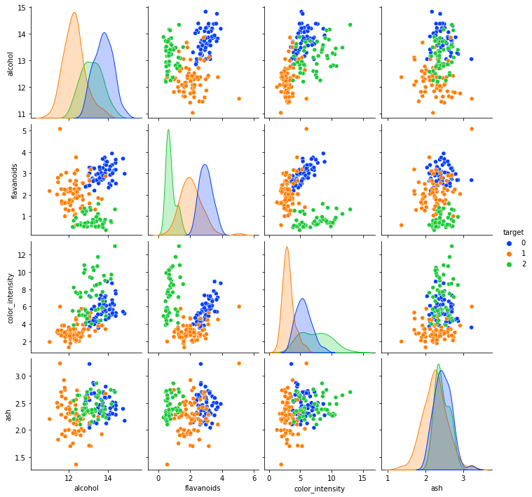

```python
# run the plotting function
myplotGrid(X,y,selected_features )
```

### 1.2. Exploratory Data Analysis under noise

When data are collected under real-world settings they usually contain some amount of noise that makes classification more challenging. In the cell below, invoke your exploratory data analysis function above on a noisy version of your data X.

Try to perturb your data with some Gaussian noise,

```
# initialize random seed to replicate results over different runs
mySeed = 12345
np.random.seed(mySeed)
XN=X+np.random.normal(0,0.6,X.shape)
```

and then invoke

```
myplotGrid(XN,y)
```

```python
# noise code
mySeed = 12345
np.random.seed(mySeed)
XN=X+np.random.normal(0,0.6,X.shape)
```

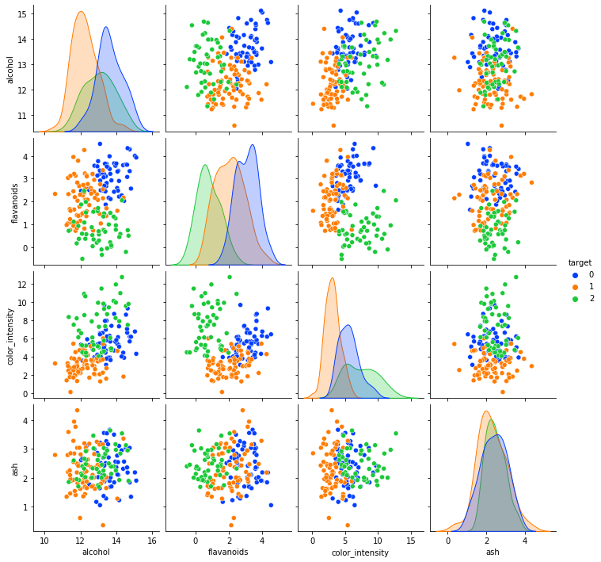

```python
myplotGrid(XN,y,selected_features)
```

### Q1. Exploratory data analysis

Based on your exploratory analysis, if you were to build a classifier using only two of the available features, which ones would you choose and why? Answer as fully as you can.

**answer:**

From the pair plot, one set of features that stands out as good possible choice for building a classifier are **{colour_intensity, alcohol}**. The data in the graph representing this set shows high directionality of the data, and appears to indicate a correlation between a change in alcohol and an increase in colour intensity. Thus, showing a strong linear relationship that would allow for using an algorithm such as **Linear Regression**. However, the data could benefit from some manipulation such as **dimensionality reduction**, **normalization**, and **noise reduction** to better illustrate and separate the different classes.

### Q2. Data with noise

What do you observe by plotting the data without noise compared to plotting with added Gaussian noise?

**answer:**

The data plotted without added noise has clearer boundaries between classes and tighter groupings of data points. The data that has gaussian noise added to it has a larger spread between the different data points and there is more overlap between classes. This means that the data with noise added may have more false positives/negatives reducing the accuracy when classifying new data. If there is enough noise in the data it could potentially even make the model fail in its ability to provide insights.

## 2. Implementing kNN

In the cell below, develop your own code for performing k-Nearest Neighbour classification. You may use the scikit-learn k-NN implementation from the labs as a guide - and as a way of verifying your results - but it is important that your implementation does not use any libraries other than the basic numpy and matplotlib functions.

Define a function that performs k-NN given a set of data. Your function should be invoked similary to:

```
    y_ = mykNN(X,y,X_,options)
```

where X is your training data, y is your training outputs, X_ are your testing data and y_ are your predicted outputs for X_. The options argument (can be a list or a set of separate arguments depending on how you choose to implement the function) should at least contain the number of neighbours to consider as well as the distance function employed.

Hint: it helps to break the problem into various sub-problems, implemented as helper function. For example, you might want to implement separate function(s) for calculating the distances between two vectors. And another function that uncovers the nearest neighbour(s) to a given vector.

## kNN Helper Code

The individual parts to assemble mykNN function

```python
# helper code

#Euclidian Distance function
def euDist(vec1,vec2):
    """
    Calculates the distance between two vectors using euclidian distance

    Input:
    vec1 = vector array 1
    vec2 = vector array 2

    Output:
    euclidian distance
    """
    d = 0.0
    for i in range(len(vec1)-1):
        d += np.power((vec1[i] - vec2[i]),2)
    return np.sqrt(d)

#Manhattan Distance Function
def manDist(vec1,vec2):
    """
    Calculates the distance between two vectors using Manhattan distance

    Input:
    vec1 = vector array 1
    vec2 = vector array 2

    Output:
    Manhatten distance
    """
    d = 0.0
    for i in range(len(vec1)-1):
        d += abs(vec1[i] - vec2[i])
    return d

#returns the nearest neighbors
def nNeighbors(tData, y, test, N, distAlgo):
    """
    Uses the provided dist(),and inbuilt sort() function to
    find the N number of closest neighbours and returns them

    Input:
    tData = list of training data
    y = the list of target values for the training data
    test = the row element for comparison to find the nearest neighbours
    N = the number of nearest neighbours we would like to find
    distAlgo = the algorithem to be used for calulating the distance between neighbours

    Output:
    returns a list of N length, of the nearest neighbours to the test element
    """
    distances = list()
    i = 0
    length=len(selected_features)
    for tData_row in tData:
        d = distAlgo(test, tData_row)
        #checks number of elements in a training data row and adds the target value to the end
        #if it is not currently there
        if(len(tData_row) == length):
            tData_row.append(y[i])
        #adds the calculated distence d to the specific element of training data
        distances.append((tData_row, d))
        i = i+1
    #sorts the list of tupples based off the distence value
    distances.sort(key=lambda x:x[1])
    neighbors = list()
    #builds the list of N closest neighbours
    for i in range(N):
        neighbors.append(distances[i][0])
    return neighbors

# Make a prediction with neighbors
def predict(tData, test, y, N, distAlgo):
    """
    Takes in the list of training data, target values, values to test,
    number of neighbours to look for and the distance algorithim to use and
    returns a list of class label predictions for the test values

    Input:
    tData = list of training data
    y = the list of target values for the training data
    test = the row element for comparison to find the nearest neighbours
    N = the number of nearest neighbours we would like to find
    distAlgo = the algorithem to be used for calulating the distance

    Output:
    The predicted label for the class of the testing data
    """
    neighbors = nNeighbors(tData, y, test, N, distAlgo)
    #uses list comprehension to build a list of classifier labels from the neariest neighbours
    output_values = [row[-1] for row in neighbors]
    #counts the class labels and returns the label with the highest count
    prediction = max(set(output_values), key=output_values.count)
    return prediction
```

## mykNN function

```python
# mykNN code
def mykNN(X, y, X_, N, distAlgo):
    """
    Trains a model for classifying and predicting the labels for a new sample of data
    using the K nearist neighbour algorithim

    Inputs:
    X = The training data for the model
    y = The class labels for the training data
    X_ = The data to classify
    N = The N neighbours to use in classifying the data
    distAlgo = The distance algorithim to use in determining the distance between neighbours

    Output:
    A list of predicted labels for the testing data givin
    """
    if(isinstance(X,np.ndarray)):
        tData = X.tolist()
    else:
        tData = X
    predictions = list()
    #creates the list of predicted labels for the new sample data
    for row in X_:
        output = predict(tData, row, y, N, distAlgo)
        predictions.append(output)
    return predictions
```

## Testing

Testing mykNN algorithem with a small sample of known data for predictions based on the Euclidian distance and Manhattan distance Functions

```python
# test evaluation code
dataset = [
    [13.77, 2.79, 6.3, 2.68],
    [13.74, 2.9,  5.85, 2.25],
    [13.56, 2.78, 6.25, 2.46],
    [14.22, 3.,   6.38, 2.3],
    [13.29, 3.23, 6.,   2.68],
    [13.72, 3.67, 6.8,  2.5],
    [12.37, 0.57, 1.95, 1.36],
    [12.33, 1.09, 3.27, 2.28],
    [12.64, 1.41, 5.75, 2.02],
    [13.67, 1.79, 3.8,  1.92],
    [12.37, 3.1,  4.45,  2.16],
    [12.17, 1.75, 2.95, 2.53]]

target = [0, 0, 0, 0, 0, 0, 1, 1, 1, 1, 1, 1]

dataset2 = [
    [14.1,  2.92,  6.2, 2.4],
    [13.94, 3.54, 8.9, 2.27],
    [13.05, 3.27, 7.2, 2.04],
    [13.83, 2.99, 5.6, 2.6],
    [13.82, 3.74, 7.05, 2.42],
    [12.37, 2.65, 4.6,  2.56],
    [13.11, 3.18, 5.3,  1.7],
    [12.37, 2.,   4.68, 1.92],
    [13.34, 1.3,  3.17, 2.36],
    [12.21, 1.28, 2.85, 1.75]]

target2 = [0, 0, 0, 0, 0, 1, 1, 1, 1, 1]


y_ = mykNN(dataset, target, dataset2, 3, euDist)

y_2 = mykNN(dataset, target, dataset2, 3, manDist)

print("\npredictions made with euclidian distance")
print(y_)
print("\npredictions made with manhattan distance")
print(y_2)
```

```
predictions made with euclidian distance
[0, 0, 0, 0, 0, 1, 0, 1, 1, 1]

predictions made with manhattan distance
[0, 0, 0, 0, 0, 1, 0, 1, 1, 1]
```

The predictions produced above when compaired to each other for the different distance calculations, and to the target data, we can see that the algorithim is performing correctly. As the predictions nearly perfictly match the target data.

## 3. Classifier evaluation

In the cell below, implement your own classifier evaluation code. This should include some way of calculating confusion matrices, as well as common metrics like accuracy.

Write some additional code that lets you display the output of your confusion matrices in a useful and easy-to-read manner.

You might want to test your functions on some test data, and compare the results to the sklearn library versions.

## Evaluation Helper Code

```python
#builds a 3x3 confusion matrix
def confusionMatrix(actual,predicted,classLabel):
    """
    Produces a 3x3 matrix from the predicted and actual class labels that allows evaluating the
    effectiveness of the kNN algorithim.

    Input:
    Actual = The list of actual target class labels
    Predicted = The list of predicted target class labels
    ClassLabel = The list of class labels from the data to build the matrix shape

    Output:
    A matrix where the rows represent the predicted data and the columns represent
    the actual data
    """
    #builds the shape of the matrix based off the number of class labels
    mshape=len(classLabel)
    m = np.zeros((mshape,mshape))
    #uses the label value as the index location for building the confusion matrix
    for i in range(len(actual)):
        m[actual[i]][predicted[i]] += 1
    return m

#builds a 4x4 confusion matrix with the ros and columns totaled
def confusionMatrixTotal(actual,predicted,classLabel):
    """
    Produces a 4x4 matrix with totaled rows and columns from the predicted and actual
    class labels that allowing evaluation of the effectiveness of the kNN algorithim.

    Input:
    Actual = The list of actual target class labels
    Predicted = The list of predicted target class labels
    ClassLabel = The list of class labels from the data to build the matrix shape

    Output:
    A matrix where the rows represent the predicted data and the columns represent
    the actual data
    """
    #builds the shap of the matrix based off the number of class labels with
    #an extra row for row and column totals
    mshape=len(classLabel)+1
    m = np.zeros((mshape,mshape))
     #uses the label value as the index location for building the confusion matrix
    for i in range(len(actual)):
        m[actual[i]][predicted[i]] += 1
    #sums the rows and columns
    for i in range(mshape):
        for j in range(mshape-1):
            m[mshape-1][i] += m[j][i]
            if i != mshape-1:
                m[i][mshape-1] += m[i][j]
    return m

#graphs the provided confusion matrix
def displayMatrix(cm):
    """
    Recieves a 3x3 or 4x4 confusion Matrix and outputs a visual heat map
    with graph labels

    Input:
    cm = 3x3 or 4x4 matrix

    Output:
    a graphed heatmap of the confusion matrix
    """
    import seaborn as sns
    labels1 = ['class0','class1','class2']
    labels2 = ['class0','class1','class2','total']
    if len(cm) == 4:
        labels = labels2
    else:
        labels = labels1
    cm_df = pd.DataFrame(cm,
                         index = labels,
                         columns = labels)

    plt.figure(figsize=(5,4))
    sns.heatmap(cm_df, annot=True)
    plt.title('Confusion Matrix')
    plt.ylabel('Actual Values')
    plt.xlabel('Predicted Values')
    plt.show()

# Calculate accuracy percentage
def accuracy(actual, predicted):
    """
    Calculates how accuratly the model predicted the labels

    Input:
    Actual = The list of actual target class labels
    Predicted = The list of predicted target class labels

    Output:
    Returns the calculated accuracy as a decimal number
    """
    correct = 0.0
    for i in range(len(actual)):
        if actual[i] == predicted[i]:
            correct += 1
    return correct / float(len(actual))

# Calculate Precision
def precision(cm):
    """
    Calculates the precision of the model

    Input:
    cm = 3x3 matrix

    Output:
    Returns the calculated pprecision as a decimal number
    """
    return np.diag(cm) / np.sum(cm, axis=0)

#Calculates Recall
def recall(cm):
    """
    Calculates the models ability to recall. Can be used as an alternate to accuracy

    Input:
    cm = 3x3 matrix

    Output:
    Returns the calculated recall as a decimal number
    """
    return np.diag(cm) / np.sum(cm, axis=1)

#Calculates the F1 Score
def f1Score(precision,recall):
    """
    Calculates the models F1 score

    Input:
    precision = a list of the precision values
    recall = a list of the recall values

    Output:
    Returns the calculated F1 Score as a decimal number
    """
    f1 = []
    for i in range(len(precision)):
        f1.append(2*((precision[i]*recall[i])/(precision[i]+recall[i])))
    return f1

# Split a dataset into k folds
def crossValSplit(data, target, nFolds, seed):
    """
    Splits the provided lists of data and targets into nFolds number of lists

    Input:
    data = The list of data to split
    targets = The lis of targets to split
    nFolds = The number of splits to create
    seed = a stabalising value for repeatability

    Output:
    Returns two lists, of length nFold lists, of the provided data
    """
    #alows for the repeatability of the same split each time
    np.random.seed(seed)
    dataSplit = list()
    targetSplit = list()
    dataCopy = list(data)
    targetCopy = list(target)
    #controls the number of folds
    foldSize = int(len(data) / nFolds)
    #repeats the process nFolds times
    for _ in range(nFolds):
        fold1 = list()
        fold2 = list()
        while len(fold1) < foldSize:
            #selects a random index in the list
            index = np.random.randint(len(dataCopy))
            fold1.append(dataCopy.pop(index))
            fold2.append(targetCopy.pop(index))
        dataSplit.append(fold1)
        targetSplit.append(fold2)
    return dataSplit,targetSplit

# Evaluate an algorithm using a cross validation split
def evaluateAlgorithm(dataset, target,algorithm, nFolds, N, distAlgo, matrixAlgo, seed):
    """
    Evaluates the performance of the kNN algorithim and returns the performance metrics

    Input:
    dataset = The training dataset
    target = The target dataset
    algorithm = The algorithim used to build the model
    nFolds = The number of folds for the model to be built off of
    N = The number of nearest neighbours to use
    distAlgo = The distance algorithim to use
    matrixAlgo = The matrix algorithim to use
    seed = A stabilising variable for repeatability of the output

    Output:
    returns a list of lists of performance metrics: confusion matrix, accuracy, precision, and F1 scores
    """
    if(isinstance(dataset,np.ndarray)):
        dataset = dataset.tolist()
    folds = crossValSplit(dataset, target, nFolds, seed)
    accuracyScores = list()
    matrix = list()
    pricisionScores = list()
    f1Scores = list()
    #selects the data to be used to train the model and the data to be used in testing the model
    for foldX,foldy in zip(folds[0],folds[1]):
        trainSet = list(folds[0])
        trainTarget = list(folds[1])
        trainSet.remove(foldX)
        trainTarget.remove(foldy)
        trainSet = sum(trainSet, [])
        trainTarget = sum(trainTarget, [])
        testSet = list()
        testTarget = list()
        for rowX,rowy in zip(foldX,foldy):
            rowXCopy = list(rowX)
            testSet.append(rowXCopy)
            testTarget.append(rowy)
        #The kNN algorithem is applied here
        predicted = algorithm(trainSet, trainTarget, testSet, N, distAlgo)
        accuracys = accuracy(testTarget, predicted)
        cm = matrixAlgo(testTarget, predicted, wine.target_names)
        pricision = precision(cm)
        recalls = recall(cm)
        accuracyScores.append(accuracys)
        matrix.append(cm)
        pricisionScores.append(precision(cm))
        f1Scores.append(f1Score(pricision,recalls))
    return matrix, accuracyScores,pricisionScores,f1Scores
```

```
############### Euclidian Distance ###############


************ Fold 1 ************
```

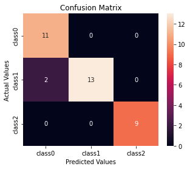

```
Accuracy: 0.942857
Precision: [0.84615385 1.         1.        ]
F1 Scores: [0.9166666666666666, 0.9285714285714286, 1.0]


************ Fold 2 ************
```

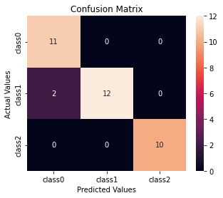

```
Accuracy: 0.942857
Precision: [0.84615385 1.         1.        ]
F1 Scores: [0.9166666666666666, 0.923076923076923, 1.0]


************ Fold 3 ************
```

```
Accuracy: 0.914286
Precision: [0.86666667 1.         0.91666667]
F1 Scores: [0.9285714285714286, 0.8421052631578948, 0.9565217391304348]


************ Fold 4 ************
```

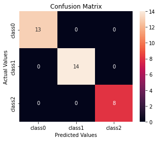

```
Accuracy: 1.000000
Precision: [1. 1. 1.]
F1 Scores: [1.0, 1.0, 1.0]


************ Fold 5 ************
```

```
Accuracy: 0.914286
Precision: [0.78571429 1.         1.        ]
F1 Scores: [0.88, 0.896551724137931, 1.0]
```

```python
# test evaluation code
print("############### Euclidian Distance ###############")
e = evaluateAlgorithm(X,y,mykNN,5,5,euDist,confusionMatrix, mySeed)
for i in range(len(e[0])):
    folds = i+1
    print("\n\n************ Fold %i ************" % folds)
    displayMatrix(e[0][i])
    print("Accuracy: %f" % e[1][i])
    print("Precision: %s" % e[2][i] )
    print("F1 Scores: %s" % e[3][i])
```

[output not shown]

```
############### Manhattan Distance ###############


************ Fold 1 ************
```

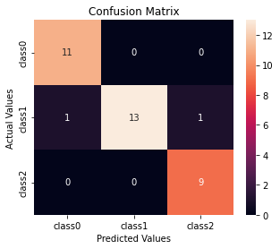

```
Accuracy: 0.942857
Precision: [0.91666667 1.         0.9       ]
F1 Scores: [0.9565217391304348, 0.9285714285714286, 0.9473684210526316]


************ Fold 2 ************
```

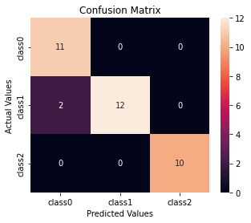

```
Accuracy: 0.942857
Precision: [0.84615385 1.         1.        ]
F1 Scores: [0.9166666666666666, 0.923076923076923, 1.0]


************ Fold 3 ************
```

```
Accuracy: 0.914286
Precision: [0.86666667 1.         0.91666667]
F1 Scores: [0.9285714285714286, 0.8421052631578948, 0.9565217391304348]


************ Fold 4 ************
```

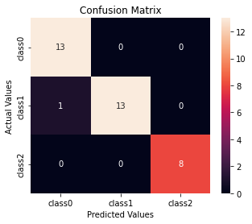

```
Accuracy: 0.971429
Precision: [0.92857143 1.         1.        ]
F1 Scores: [0.962962962962963, 0.962962962962963, 1.0]


************ Fold 5 ************
```

```
Accuracy: 0.914286
Precision: [0.78571429 1.         1.        ]
F1 Scores: [0.88, 0.896551724137931, 1.0]
```

```python
print("\n\n############### Manhattan Distance ###############")
e = evaluateAlgorithm(X,y,mykNN,5,5,manDist,confusionMatrix, mySeed)
for i in range(len(e[0])):
    folds = i+1
    print("\n\n************ Fold %i ************" % folds)
    displayMatrix(e[0][i])
    print("Accuracy: %f" % e[1][i])
    print("Precision: %s" % e[2][i] )
    print("F1 Scores: %s" % e[3][i])
```

[output not shown]

## 4. Nested Cross-validation using your implementation of KNN

In the cell below, develop your own code for performing 5-fold nested cross-validation along with your implemenation of k-NN above. You must write your own code -- the scikit-learn module may only be used for verification purposes.

Your code for nested cross-validation should invoke your kNN function (see above). You cross validation function should be invoked similary to:

```
accuracies_fold = myNestedCrossVal(X,y,5,list(range(1,11)),['euclidean','manhattan'],mySeed)
```

where X is your data matrix (containing all samples and features for each sample), 5 is the number of folds, y are your known output labels, `list(range(1,11)` evaluates the neighbour parameter from 1 to 10, and `['euclidean','manhattan',...]` evaluates the distances on the validation sets. mySeed is simply a random seed to enable us to replicate your results.

**Notes:**

- you should perform nested cross-validation on **both** your original data X, as well as the data pertrubed by noise as shown in the cells above (XN)
- you should evaluate **at least** two distance functions
- you should evaluate number of neighbours from 1 to 10
- your function should return a list of accuracies per fold
- for each **fold**, your function should print:
  - the accuracy per distinct set of parameters on the validation set
  - the best set of parameters for the fold after validation
  - the confusion matrix per fold (on the testing set)

## Helper Code

```python
def nestedEvaluateAlgorithm(dataset, target,algorithm, nFolds, N, distAlgo, seed):
    """
    Evaluates the performance of the nested kNN algorithim and returns the performance metrics
    to be used in determining the best hyper parameters

    Input:
    dataset = The training dataset
    target = The target dataset
    algorithm = The algorithim used to build the model
    nFolds = The number of folds for the model to be built off of
    N = The number of nearest neighbours to use
    distAlgo = The distance algorithim to use
    matrixAlgo = The matrix algorithim to use
    seed = A stabilising variable for repeatability of the output

    Output:
    returns average accuracy score of a fold
    """
    if(isinstance(dataset,np.ndarray)):
        dataset = dataset.tolist()
    folds = crossValSplit(dataset, target, nFolds, seed)
    accuracyScores = list()
    #selects the data to be used to train the model and the data to be used in testing the model
    for foldX,foldy in zip(folds[0],folds[1]):
        trainSet = list(folds[0])
        trainTarget = list(folds[1])
        trainSet.remove(foldX)
        trainTarget.remove(foldy)
        trainSet = sum(trainSet, [])
        trainTarget = sum(trainTarget, [])
        testSet = list()
        testTarget = list()
        for rowX,rowy in zip(foldX,foldy):
            rowXCopy = list(rowX)
            testSet.append(rowXCopy)
            testTarget.append(rowy)
        #The kNN algorithem is applied here
        predicted = algorithm(trainSet, trainTarget, testSet, N, distAlgo)
        accuracys = accuracy(testTarget, predicted)
        accuracyScores.append(accuracys)
    avgAccuracy = (sum(accuracyScores)/len(accuracyScores))*100

    return avgAccuracy
```

## Nested Cross Validation Algorithm

```python
# myNestedCrossVal code
def myNestedCrossVal(X,y,nFolds,N,distAlgo,matrixAlgo,seed):
    """
    Evaluates the performance of the kNN algorithim and
    hyper parameters with a nested validation operation
    inorder to optimise the returned performance metrics

    Input:
    X = The training dataset
    y = The target dataset
    nFolds = The number of folds for the model to be built off of
    N = The number of nearest neighbours to use
    distAlgo = The distance algorithim to use
    matrixAlgo = The matrix algorithim to use
    seed = A stabilising variable for repeatability of the output

    Output:
    returns a list of lists of performance metrics: confusion matrix, accuracy, precision, and F1 scores
    """
    if(isinstance(X,np.ndarray)):
        X = X.tolist()
    folds = crossValSplit(X, y, nFolds,seed)
    accuracyScores = list()
    matrix = list()
    pricisionScores = list()
    f1Scores = list()
    foldCount = 1
    #selects the data to be used to train the model and the data to be used in testing the model
    for foldX,foldy in zip(folds[0],folds[1]):
        trainSet = list(folds[0])
        trainTarget = list(folds[1])
        trainSet.remove(foldX)
        trainTarget.remove(foldy)
        trainSet = sum(trainSet, [])
        trainTarget = sum(trainTarget, [])
        valAccuracy = 0
        k=0
        dist=0
        #the nested crossvalidation for validating the model
        print("Valadating Fold %i" % foldCount)
        for i in range(len(N)):
            for j in range(len(distAlgo)):
                val = nestedEvaluateAlgorithm(trainSet, trainTarget, mykNN, nFolds, N[i], distAlgo[j], seed)
                print('Mean Accuracy: %.3f%%' % val + ' K = %i'% N[i] + ' Distance Function: %s' % distAlgo[j])
                if(val >= valAccuracy):
                    valAccuracy = val
                    k =N[i]
                    dist = distAlgo[j]
        print("\nThe Best parameters of this run are:")
        print('Accuracy: %.3f%%' % valAccuracy + '  k = %i' % k)
        print('Distance Algo:  %s' % dist)
        print("\n")

        testSet = list()
        testTarget = list()
        for rowX,rowy in zip(foldX,foldy):
            rowXCopy = list(rowX)
            testSet.append(rowXCopy)
            testTarget.append(rowy)
        #The kNN algorithem is applied here
        predicted = mykNN(trainSet, trainTarget, testSet, k, dist)
        cm = matrixAlgo(testTarget, predicted, wine.target_names)
        accuracys = accuracy(testTarget, predicted)
        pricision = precision(cm)
        recalls = recall(cm)
        print('Fold %i' % foldCount +' Confusion Matrix: \n%s\n' % cm)
        matrix.append(cm)
        accuracyScores.append(accuracys)
        pricisionScores.append(precision(cm))
        f1Scores.append(f1Score(pricision,recalls))
        foldCount += 1
    return matrix,accuracyScores, pricisionScores,f1Scores
```

## Clean Data Evaluation

```python
# evaluate clean data code

accuracies_fold = myNestedCrossVal(X,y,5,list(range(1,11)),[euDist,manDist],confusionMatrix, 12345)
```

```
Valadating Fold 1
Mean Accuracy: 92.857% K = 1 Distance Function: <function euDist at 0x000001B1D1A94670>
Mean Accuracy: 94.286% K = 1 Distance Function: <function manDist at 0x000001B1D1A943A0>
Mean Accuracy: 92.143% K = 2 Distance Function: <function euDist at 0x000001B1D1A94670>
Mean Accuracy: 92.857% K = 2 Distance Function: <function manDist at 0x000001B1D1A943A0>
Mean Accuracy: 92.143% K = 3 Distance Function: <function euDist at 0x000001B1D1A94670>
Mean Accuracy: 92.857% K = 3 Distance Function: <function manDist at 0x000001B1D1A943A0>
Mean Accuracy: 92.143% K = 4 Distance Function: <function euDist at 0x000001B1D1A94670>
Mean Accuracy: 92.143% K = 4 Distance Function: <function manDist at 0x000001B1D1A943A0>
Mean Accuracy: 92.143% K = 5 Distance Function: <function euDist at 0x000001B1D1A94670>
Mean Accuracy: 93.571% K = 5 Distance Function: <function manDist at 0x000001B1D1A943A0>
Mean Accuracy: 91.429% K = 6 Distance Function: <function euDist at 0x000001B1D1A94670>
Mean Accuracy: 92.143% K = 6 Distance Function: <function manDist at 0x000001B1D1A943A0>
Mean Accuracy: 92.143% K = 7 Distance Function: <function euDist at 0x000001B1D1A94670>
Mean Accuracy: 92.857% K = 7 Distance Function: <function manDist at 0x000001B1D1A943A0>
Mean Accuracy: 90.714% K = 8 Distance Function: <function euDist at 0x000001B1D1A94670>
Mean Accuracy: 92.857% K = 8 Distance Function: <function manDist at 0x000001B1D1A943A0>
Mean Accuracy: 91.429% K = 9 Distance Function: <function euDist at 0x000001B1D1A94670>
Mean Accuracy: 92.857% K = 9 Distance Function: <function manDist at 0x000001B1D1A943A0>
Mean Accuracy: 91.429% K = 10 Distance Function: <function euDist at 0x000001B1D1A94670>
Mean Accuracy: 92.143% K = 10 Distance Function: <function manDist at 0x000001B1D1A943A0>

The Best parameters of this run are:
Accuracy: 94.286%  k = 1
Distance Algo:  <function manDist at 0x000001B1D1A943A0>


Fold 1 Confusion Matrix:
[[11.  0.  0.]
 [ 1. 13.  1.]
 [ 0.  0.  9.]]

Valadating Fold 2
Mean Accuracy: 91.429% K = 1 Distance Function: <function euDist at 0x000001B1D1A94670>
Mean Accuracy: 92.143% K = 1 Distance Function: <function manDist at 0x000001B1D1A943A0>
Mean Accuracy: 94.286% K = 2 Distance Function: <function euDist at 0x000001B1D1A94670>
Mean Accuracy: 92.143% K = 2 Distance Function: <function manDist at 0x000001B1D1A943A0>
Mean Accuracy: 93.571% K = 3 Distance Function: <function euDist at 0x000001B1D1A94670>
Mean Accuracy: 93.571% K = 3 Distance Function: <function manDist at 0x000001B1D1A943A0>
Mean Accuracy: 90.714% K = 4 Distance Function: <function euDist at 0x000001B1D1A94670>
```

[output cut: 104 more lines]

```
Mean Accuracy: 91.429% K = 8 Distance Function: <function manDist at 0x000001B1D1A943A0>
Mean Accuracy: 90.714% K = 9 Distance Function: <function euDist at 0x000001B1D1A94670>
Mean Accuracy: 91.429% K = 9 Distance Function: <function manDist at 0x000001B1D1A943A0>
Mean Accuracy: 90.000% K = 10 Distance Function: <function euDist at 0x000001B1D1A94670>
Mean Accuracy: 91.429% K = 10 Distance Function: <function manDist at 0x000001B1D1A943A0>

The Best parameters of this run are:
Accuracy: 93.571%  k = 5
Distance Algo:  <function manDist at 0x000001B1D1A943A0>


Fold 5 Confusion Matrix:
[[11.  0.  0.]
 [ 3. 13.  0.]
 [ 0.  0.  8.]]
```

### Summaries

```
**Average Confusion Matrix for Clean Data**
```

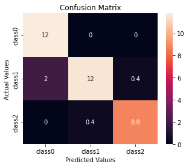

```
accuracy for fold 1 in decimal 0.942857
accuracy for fold 2 in decimal 0.857143
accuracy for fold 3 in decimal 0.914286
accuracy for fold 4 in decimal 0.971429
accuracy for fold 5 in decimal 0.914286
The average Accuracy is 0.920000
```

```python
# Print the summaries
print("**Average Confusion Matrix for Clean Data**")
displayMatrix(sum(accuracies_fold[0])/len(accuracies_fold[0]))
for i in range (len(accuracies_fold[1])):
    folds = i+1
    print('accuracy for fold %i' % folds + ' in decimal %f' % accuracies_fold[1][i] )
avg = avg=sum(accuracies_fold[1])/len(accuracies_fold[1])
print('The average Accuracy is %f' % avg)
```

## Noisy Data Evaluation

```python
# evaluate noisy  data code
Naccuracies_fold =  myNestedCrossVal(XN,y,5,list(range(1,11)),[euDist,manDist],confusionMatrix,mySeed)
```

```
Valadating Fold 1
Mean Accuracy: 85.714% K = 1 Distance Function: <function euDist at 0x000001B1D1A94670>
Mean Accuracy: 85.714% K = 1 Distance Function: <function manDist at 0x000001B1D1A943A0>
Mean Accuracy: 82.857% K = 2 Distance Function: <function euDist at 0x000001B1D1A94670>
Mean Accuracy: 82.857% K = 2 Distance Function: <function manDist at 0x000001B1D1A943A0>
Mean Accuracy: 86.429% K = 3 Distance Function: <function euDist at 0x000001B1D1A94670>
Mean Accuracy: 87.857% K = 3 Distance Function: <function manDist at 0x000001B1D1A943A0>
Mean Accuracy: 87.143% K = 4 Distance Function: <function euDist at 0x000001B1D1A94670>
Mean Accuracy: 85.714% K = 4 Distance Function: <function manDist at 0x000001B1D1A943A0>
Mean Accuracy: 87.857% K = 5 Distance Function: <function euDist at 0x000001B1D1A94670>
Mean Accuracy: 85.714% K = 5 Distance Function: <function manDist at 0x000001B1D1A943A0>
Mean Accuracy: 87.143% K = 6 Distance Function: <function euDist at 0x000001B1D1A94670>
Mean Accuracy: 87.857% K = 6 Distance Function: <function manDist at 0x000001B1D1A943A0>
Mean Accuracy: 89.286% K = 7 Distance Function: <function euDist at 0x000001B1D1A94670>
Mean Accuracy: 88.571% K = 7 Distance Function: <function manDist at 0x000001B1D1A943A0>
Mean Accuracy: 87.857% K = 8 Distance Function: <function euDist at 0x000001B1D1A94670>
Mean Accuracy: 88.571% K = 8 Distance Function: <function manDist at 0x000001B1D1A943A0>
Mean Accuracy: 88.571% K = 9 Distance Function: <function euDist at 0x000001B1D1A94670>
Mean Accuracy: 90.000% K = 9 Distance Function: <function manDist at 0x000001B1D1A943A0>
Mean Accuracy: 86.429% K = 10 Distance Function: <function euDist at 0x000001B1D1A94670>
Mean Accuracy: 87.857% K = 10 Distance Function: <function manDist at 0x000001B1D1A943A0>

The Best parameters of this run are:
Accuracy: 90.000%  k = 9
Distance Algo:  <function manDist at 0x000001B1D1A943A0>


Fold 1 Confusion Matrix:
[[10.  0.  1.]
 [ 3. 12.  0.]
 [ 0.  0.  9.]]

Valadating Fold 2
Mean Accuracy: 82.857% K = 1 Distance Function: <function euDist at 0x000001B1D1A94670>
Mean Accuracy: 82.143% K = 1 Distance Function: <function manDist at 0x000001B1D1A943A0>
Mean Accuracy: 80.000% K = 2 Distance Function: <function euDist at 0x000001B1D1A94670>
Mean Accuracy: 82.143% K = 2 Distance Function: <function manDist at 0x000001B1D1A943A0>
Mean Accuracy: 86.429% K = 3 Distance Function: <function euDist at 0x000001B1D1A94670>
Mean Accuracy: 85.714% K = 3 Distance Function: <function manDist at 0x000001B1D1A943A0>
Mean Accuracy: 85.000% K = 4 Distance Function: <function euDist at 0x000001B1D1A94670>
```

[output cut: 104 more lines]

```
Mean Accuracy: 90.714% K = 8 Distance Function: <function manDist at 0x000001B1D1A943A0>
Mean Accuracy: 90.714% K = 9 Distance Function: <function euDist at 0x000001B1D1A94670>
Mean Accuracy: 89.286% K = 9 Distance Function: <function manDist at 0x000001B1D1A943A0>
Mean Accuracy: 89.286% K = 10 Distance Function: <function euDist at 0x000001B1D1A94670>
Mean Accuracy: 90.000% K = 10 Distance Function: <function manDist at 0x000001B1D1A943A0>

The Best parameters of this run are:
Accuracy: 91.429%  k = 8
Distance Algo:  <function euDist at 0x000001B1D1A94670>


Fold 5 Confusion Matrix:
[[ 9.  2.  0.]
 [ 1. 15.  0.]
 [ 0.  0.  8.]]
```

### Summaries

```
**Average Confusion Matrix for Noisy Data**
```

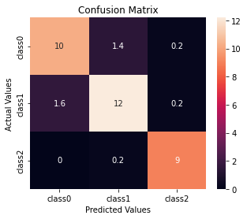

```
accuracy for fold 1 in decimal 0.885714
accuracy for fold 2 in decimal 0.857143
accuracy for fold 3 in decimal 0.914286
accuracy for fold 4 in decimal 0.914286
accuracy for fold 5 in decimal 0.914286
The average Accuracy is 0.897143
```

```python
# Print the summaries
print("**Average Confusion Matrix for Noisy Data**")
displayMatrix(sum(Naccuracies_fold[0])/len(Naccuracies_fold[0]))
for i in range (len(Naccuracies_fold[1])):
    folds = i+1
    print('accuracy for fold %i' % folds + ' in decimal %f' % Naccuracies_fold[1][i] )
avg = avg=sum(Naccuracies_fold[1])/len(Naccuracies_fold[1])
print('The average Accuracy is %f' % avg)
```

## 5. Summary of results

Using your results from above, fill out the following table using the **clean** data:

| Fold | accuracy | k | distance |
| --- | --- | --- | --- |
| 1 | 94.286 | 1 | Manhattan |
| 2 | 85.714 | 2 | euclidian |
| 3 | 91.428 | 7 | Manhattan |
| 4 | 97.142 | 5 | Manhattan |
| 5 | 91.428 | 5 | Manhattan |
| **total** | 92 $\pm$ 3.79 |  |  |

Where **total** is given as an average over all the folds, and $\pm$ the standard deviation.

Now fill out the following table using the **noisy** data:

| Fold | accuracy | k | distance |
| --- | --- | --- | --- |
| 1 | 88.571 | 9 | Manhattan |
| 2 | 85.714 | 9 | Manhattan |
| 3 | 91.428 | 10 | Manhattan |
| 4 | 91.428 | 8 | Euclidian |
| 5 | 91.428 | 8 | Euclidian |
| **total** | 89.714 $\pm$ 2.286 |  |  |

### 5.2. Confusion matrix summary

Summarise the overall results of your nested cross validation evaluation of your K-NN algorithm using two summary confusion matrices (one for the noisy data, one for the clean data). You might want to adapt your `myNestedCrossVal` code above to also return a list of confusion matrices.

Use or adapt your evaluation code above to print the two confusion matrices below. Make sure you label the matrix rows and columns. You might also want ot show class-relative precision and recall.

```
**********************CLEAN DATA**********************


************ Fold 1 ************
```

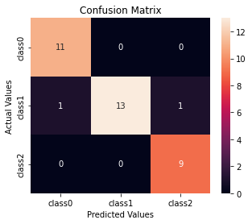

```
Accuracy: 0.942857
Precision: [0.91666667 1.         0.9       ]
F1 Scores: [0.9565217391304348, 0.9285714285714286, 0.9473684210526316]


************ Fold 2 ************
```

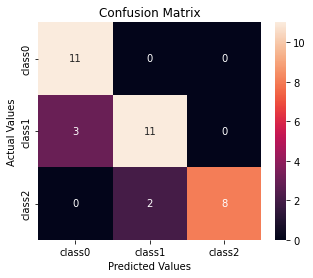

```
Accuracy: 0.857143
Precision: [0.78571429 0.84615385 1.        ]
F1 Scores: [0.88, 0.8148148148148148, 0.888888888888889]


************ Fold 3 ************
```

```
Accuracy: 0.914286
Precision: [0.86666667 1.         0.91666667]
F1 Scores: [0.9285714285714286, 0.8421052631578948, 0.9565217391304348]


************ Fold 4 ************
```

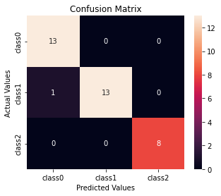

```
Accuracy: 0.971429
Precision: [0.92857143 1.         1.        ]
F1 Scores: [0.962962962962963, 0.962962962962963, 1.0]


************ Fold 5 ************
```

```
Accuracy: 0.914286
Precision: [0.78571429 1.         1.        ]
F1 Scores: [0.88, 0.896551724137931, 1.0]


**********************NOISY DATA**********************


************ Fold 1 ************
```

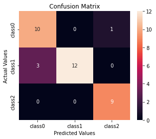

```
Accuracy: 0.885714
Precision: [0.76923077 1.         0.9       ]
F1 Scores: [0.8333333333333333, 0.888888888888889, 0.9473684210526316]


************ Fold 2 ************
```

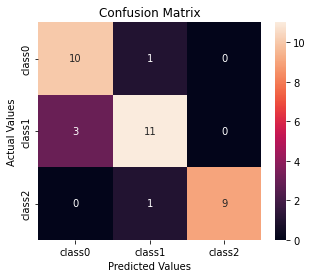

```
Accuracy: 0.857143
Precision: [0.76923077 0.84615385 1.        ]
F1 Scores: [0.8333333333333333, 0.8148148148148148, 0.9473684210526316]


************ Fold 3 ************
```

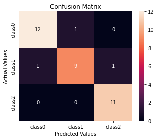

```
Accuracy: 0.914286
Precision: [0.92307692 0.9        0.91666667]
F1 Scores: [0.9230769230769231, 0.8571428571428572, 0.9565217391304348]


************ Fold 4 ************
```

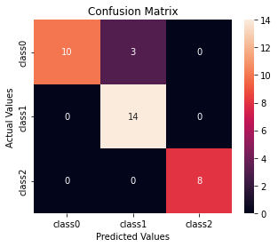

```
Accuracy: 0.914286
Precision: [1.         0.82352941 1.        ]
F1 Scores: [0.8695652173913044, 0.9032258064516129, 1.0]


************ Fold 5 ************
```

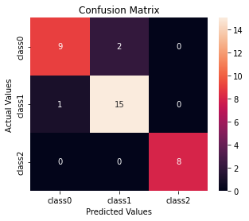

```
Accuracy: 0.914286
Precision: [0.9        0.88235294 1.        ]
F1 Scores: [0.8571428571428572, 0.9090909090909091, 1.0]
```

```python
print('**********************CLEAN DATA**********************')
# clean data summary results
for i in range(len(accuracies_fold[0])):
    folds = i+1
    print("\n\n************ Fold %i ************" % folds)
    displayMatrix(accuracies_fold[0][i])
    print("Accuracy: %f" % accuracies_fold[1][i])
    print("Precision: %s" % accuracies_fold[2][i] )
    print("F1 Scores: %s" % accuracies_fold[3][i])

print('\n\n**********************NOISY DATA**********************')
# clean data summary results
for i in range(len(Naccuracies_fold[0])):
    folds = i+1
    print("\n\n************ Fold %i ************" % folds)
    displayMatrix(Naccuracies_fold[0][i])
    print("Accuracy: %f" % Naccuracies_fold[1][i])
    print("Precision: %s" % Naccuracies_fold[2][i] )
    print("F1 Scores: %s" % Naccuracies_fold[3][i])
```

[output not shown]

## 6. More questions

Now answer the following questions as fully as you can. The answers should be based on your implementation above. Write your answers in the Markdown cells below each question.

### Q3. Influence of noise

Do the best parameters change when noise is added to the data? Can you say that one parameter choice is better regardless of the data used?

**Answer:**

There was a distinct difference in the majority of best parameters between the noisy data and the regular data. The results showed that the parameters chosen are quite dataset specific. Which we can see from the larger K value needed for the noisy data to return similar levels of accuracy as the clean data. The one parameter that appeared to shine regardless of the data was the best performing distance algorithm the Manhattan distance.

### Q4. Tie break

Assume that you have selected the number of neighbours to be an even number, e.g., 2. For one of the neighbours, the suggested class is 1, and for the other neighbour the suggested class is 2. How would you break the tie? Write example pseudocode that does this.

**Answer:**

A potential solution to the problem of a tie is temporarily reducing the number of Neighbours being looked at until an obvious class has been given. This could be considered an example of placing a higher value weight on the first nearest Neighbour vs the second.

given the example of 2 Neighbours with different classes but equal distance apart:

**pseudocode**

```
k = 2

if k1 nearest Neighbour distance is equal to k2 nearest Neighbour distance

    if k1 class not equal to k2 class

        k - 1

        class is equal to k1 class

        k = 2
```

This solution works because it eliminates the possibility of an unbalanced tie. It would also solve many of the other possible tie cases. Alternativly, we could also increase the k number of Neighbours we are looking at untill the tie is broken.

### Q5. Beyond Wine

If you were to run your k-nn algorithm on a new dataset (e.g., the breast cancer dataset, or Iris), what considerations would you need to take into consideration? Outline any changes that might be needed to your code.

**Answer:**

The Iris dataset is structured similar to the wine dataset in that it has 3 classes. with very minimal modification to mykNN the model could be trained and tested. However, the breast cancer dataset is a binary classification set where the classes are 'malignant' or 'benign'. The biggest change to the code would be involved in dealing with a smaller confusion matrix, as the current function for displaying the matrix is hard coded to have at least 3 labels. Moreover, the bigger concern would be if the data was properly sanitized. In a situation where it wasn't, and it was intended for the algorithm to be able to deal with missing data points automagically. Then a data cleaning function would need to be implemented.